# Land Use Classification and Machine Learning

## ZFL, Bonn March/April 2019

### Mort Canty

mort.canty@gmail.com

### Outline

Land cover classification of remote sensing imagery is a task which falls into the general category of **pattern recognition**. Pattern recognition problems, in turn, are usually approached by developing appropriate **machine learning algorithms**. Broadly speaking, machine learning involves tasks for which there is no known direct method to compute a desired output from a set of inputs. The strategy adopted is for the computer to learn from a set of representative examples.

In the case of supervised classification, the task can often be seen as one of modeling **probability distributions**. This is called the **training phase** of the classification procedure. Then these probabilities are used to classify all of the pixels in the image, a step referred to as the **generalization phase**.

The course will treat three representative models for supervised classification which involve probability estimation: a **parametric model** (the Bayes maximum likelihood classifier), a **nonparametric model** (kernel density estimation), and a **semiparametric or mixture model** (the feed-forward neural network or FFN). In addition statistical methods for accuracy assessment and model comparison will be discussed.

The theory will be illustrated with Python programs for classification and evaluation, both for local processing as well as on the **Google Earth Engine**. In the case of neural networks, **deep learning** techniques with **TensorFlow** will be introduced.

### Software

https://mortcanty.github.io/CRC4Docker/

https://docs.docker.com/

### References

https://www.crcpress.com/Image-Analysis-Classification-and-Change-Detection-in-Remote-Sensing-With/Canty/p/book/9781138613225

https://www.amazon.de/Hands-Machine-Learning-Scikit-Learn-TensorFlow/dp/1491962291/ref=sr_1_1?ie=UTF8&qid=1550754549&sr=8-1&keywords=geron+hands-on+machine

## Bayes Maximum Likelihood Classifier (parametric model)

#### Decision rule

$$ g \hbox{ is in class } k\hbox{ provided } Pr(k\mid g) \ge Pr(j\mid g)\hbox{ for all } j=1\dots K $$

#### Bayes' Rule

$$ Pr(k\mid g) =\ \ ? \quad\to \quad Pr(k\mid g) \approx Pr(k) \quad\to \quad Pr(k\mid g) = {p(g\mid k)\over p(g)} Pr(k) $$

#### All priors equal

$$ g \hbox{ is in class } k\hbox{ provided } p(g\mid k) \ge p(g\mid j)\hbox{ for all } j=1\dots K $$

#### Gaussian model assumption

$$ p(g\mid k)={1\over (2\pi)^{N/2}\vert\Sigma_k\vert^{1/2}}\exp\left( -{1\over 2} (g-\mu_k)^\top \Sigma_k^{-1} (g-\mu_k) \right). $$

#### Taking logarithm and ignoring class-independent terms

$$ g \hbox{ is in class } k\hbox{ provided } d_k(g) \ge d_j(g)\hbox{ for all } j=1\dots K. $$

#### where

$$ d_k(g) = -\log\vert\Sigma_k\vert - (g-\mu_k)^\top \Sigma_k^{-1} (g-\mu_k). $$

## Training data separability

#### The Bayes error for a binary classifier:

$$ \epsilon = \int\min[\ Pr(1\mid g),Pr(2\mid g)\ ]p(g)dg = \int\min[\ p(g\mid 1)Pr(1),p(g\mid 2)Pr(2)\ ]dg. $$

#### If the two probability densities are assumed to be Gaussian, we get

$$ \epsilon\le\epsilon_B =\sqrt{Pr(1)Pr(2)}\int \sqrt{p(g\mid 1)p(g\mid 2)}\ dg = \sqrt{Pr(1)Pr(2)}\ e^{-B}, $$

#### where the Bhattacharyya distance between is:

$$ B = {1\over 8}(\mu_2-\mu_1)^\top \left[{\Sigma_1+\Sigma_2\over 2}\right]^{-1} (\mu_2-\mu_1) +{1\over 2}\log\left({\left|\Sigma_1+\Sigma_2\right|/2\over \sqrt{|\Sigma_1||\Sigma_2|}}\right). $$

#### Larger values of $B$ imply smaller Bayes error. The Jeffries-Matusita separability measure is defined in terms of $B$ as

$$ J = 2(1-e^{-B}) $$

## Gauss Kernel Classifier (non-parametric model)

#### For training vectors $g(\nu)$, $\nu=1\dots m$, the contribution to the probability density at the point $g(\nu)$ from class $k$ is

$$ p(g(\nu)\mid k) = {1\over m_k}\sum_{\{\nu'\mid \ell(\nu') = k\}} \exp\left(-{\|g(\nu)-g(\nu')\|^2\over 2\sigma^2}\right) = {1\over m_k}\sum_{\{\nu'\mid \ell(\nu') = k\}}(\mathcal{K})_{\nu\nu'}, $$

#### where $\mathcal{K}$ is an $m\times m$ *Gaussian kernel matrix* and $\ell(\nu)$ is the class label.

#### With the rule, choose class $k$ if

$$ p(g\mid k) \ge p(g\mid j),\quad j=1\dots K, $$

#### training involves finding the value of $\sigma$ which minimizes the classification error on the training data themselves.

## Feed Forward Neural Network (mixture model)

### Motivation (for two classes of two-dimensional observations)

#### Discriminant function

$$ I(g) = d_1(g) - d_2(g) $$$$ g\ \hbox{ is class }\cases{1 & if $I(g)\ge0$\cr 2 & if $I(g)<0$.} $$

#### Simplest discriminant

$$ I(g) = w_0 + w_1g_1+w_2g_2 $$

#### Decision boundary $I(g)=0)$

$$ g_2 = -{w_1\over w_2}g_1-{w_0\over w_2}, $$

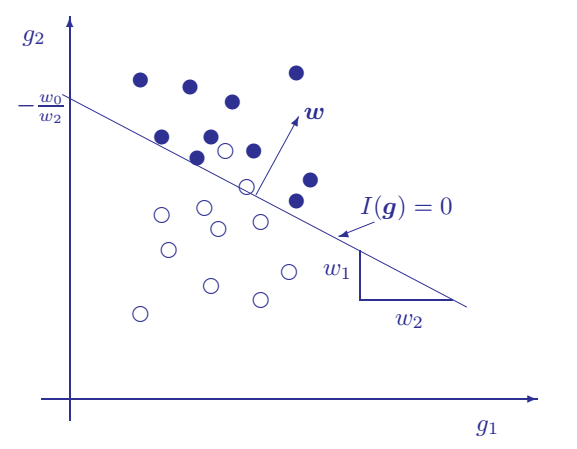

```python
Image(filename="pngs/fig2.png",width=600,height=600)
```

#### For N-dimensional observations this becomes an *oriented hyperplane*

$$ I(g) = w_0+w_1g_1+\dots+w_Ng_N = w^\top g+w_0 $$

#### This can be represented graphically as a *perceptron* or *artificial neuron*

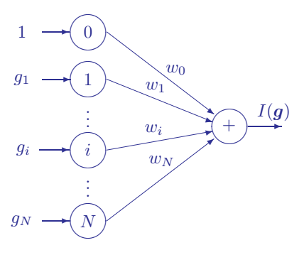

```python
Image(filename="pngs/fig3.png",width=600,height=600)
```

#### Some jargon:

$g_1\dots g_N$ **input signals**

$w_1\dots W_N$ **synaptic weights**

$w_0$ **bias**

$I(g)$ **output signal**, which is modified by a non-linear **activation function** such as

$$ f(g) = {1\over 1 + e^{-I(g)}} $$

#### For just two Gaussian classes, $\Sigma_1=\Sigma_2$, it is easy to show (text, Chapter 6) that

$$ Pr(1\mid g) = {p(g\mid 1)Pr(1)\over p(g\mid 1)Pr(1)+p(g\mid 2)pr(2)} = {1\over 1 + e^{-I(g)}} = f(g) $$

We expect that the output signal $f(g)$ of the neuron will not only discriminate between the two classes, **but also that it will approximate the posterior class membership probability** $Pr(1\mid g)$.

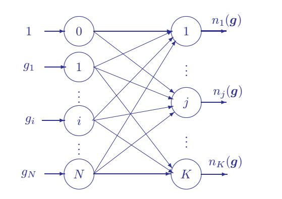

```python
Image(filename="pngs/fig4.png",width=600,height=600)
```

**There are $K$ neurons (the circles on the right), each of which calculates its own discriminant**

$$ n_j(g)=f(I_j(g)),\ j=1\dots K. $$$$ k = \arg\max_j n_j(g). $$

**For the $j$th neuron,**

$$ w_j = (w_{0j},w_{1j}\dots w_{Nj})^\top, $$

**and, for the whole network,**

$$ W = (w_1,w_2\dots w_K) = \pmatrix{ w_{01} & w_{02} & \cdots & w_{0K}\cr w_{11} & w_{12} & \cdots & w_{1K}\cr \vdots & \vdots & \ddots & \vdots\cr w_{N1} & w_{N2} & \cdots & w_{NK} }, $$

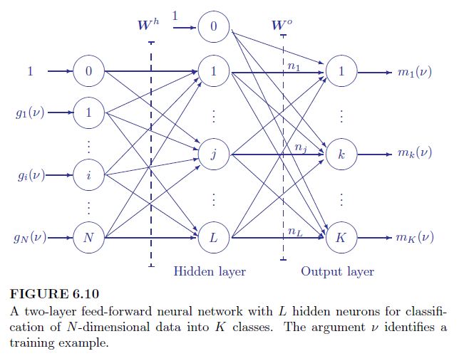

```python
Image(filename="pngs/fig5.png",width=600,height=600)
```

**Input**

$$ g(\nu) = (1,g_1(\nu)\dots g_N(\nu))^\top. $$

**Hidden layer** $$ n(\nu)=(1,n_1(\nu)\dots n_L(\nu))^\top $$

$$ n_j(\nu) = f(I^h_j(g(\nu))),\quad j=1\dots L. $$$$ I^h_j(g(\nu)) =w^{h\top}_j g(\nu), $$$$ n(\nu) = \pmatrix{ 1 \cr f(W^{h\top} g(\nu))} $$

**Output layer**

$$ m(\nu) = f(W^{o\top}n(\nu)) $$

**Softmax**

$$ m_k(\nu) = {e^{I^o_k(n(\nu))}\over e^{I^o_1(n(\nu))}+e^{I^o_2(n(\nu))}+\dots + e^{I^o_K( n(\nu))}} $$

**where**

$$ I^o_k(n(\nu)) = w^{o\top}_k n(\nu), \quad k=1\dots K $$

**Bishop (1995):**

**Two-layer, feed-forward networks can approximate arbitrarily well any functional continuous mapping from one finite dimensional space to another, provided the number of hidden units is sufficiently large. ... An important corollary of this result is, that in the context of a classification problem, networks with sigmoidal non-linearities and two layers of weights can approximate any decision boundary to arbitrary accuracy. ... More generally, the capability of such networks to approximate general smooth functions allows them to model posterior probabilities of class membership.**

### Cost function (catagorical cross-entropy)

**Training set**

$$ \mathcal{T}=\{(g(\nu),\ell(\nu))\mid \nu=1\dots m\}, $$

**"One-hot" encoding**

$$ \ell(\nu) = (0\dots 0,1,0\dots 0)^\top $$

**Training: Maximize the probability of observing the earch training example (definition of conditional proabability)**

$$ Pr(g(\nu),\ell(\nu)) = Pr(\ell(\nu)\mid g(\nu))\Pr(g(\nu)) = \prod_{k=1}^K [\ m_k(g(\nu))\ ]^{\ell_k(\nu)} $$

**for example:**

$$ Pr((1,0\dots 0)^\top \mid g) = m_1(g)^1 \cdot m_2(g)^0 \cdots m_K( g)^0 = m_1(g), $$

**Take negative logarithm, and drop terms independent of the synaptic weights**

$$ E(W^h,W^o) = - \sum_{k=1}^K \ell_k(\nu)\log [m_k(g(\nu))] \to \min $$

**In vector notation**

$$ E(\nu) = - \ell(\nu)^\top\log[m(\nu)] $$

#### Backpropagation algorithm (stochastic)

1. Initialize the synaptic weights with random numbers and set $\nu$ equal to a random integer in the interval $[1,m]$.
2. Choose training pair $(g(\nu),\ell(\nu))$ and determine the output response $m(\nu)$ of the network.
3. For $k=1\dots K$ and $j=0\dots L$, replace $w^o_{jk}$ with $w^o_{jk}-\eta{\partial E(\nu)\over\partial w^o_{jk}}$.
4. For $j=1\dots L$ and $i=0\dots N$, replace $w^h_{ij}$ with $w^h_{ij}-\eta{\partial E(\nu)\over\partial w^h_{ij}}$.
5. If $\sum_\nu E(\nu)$ ceases to change significantly, stop, otherwise set $\nu$ equal to a new random integer in $[1,m]$ and go to step 2.

This is a **gradient descent** algorithm. If we evaluate the parial derivatives we get

$$ W^o(\nu+1) = W^o(\nu) + \eta\ n(\nu) \delta^o(\nu)^\top $$$$ \delta^o(\nu) = \ell(\nu)- m(\nu) $$

$$ W^h(\nu+1) = W^h(\nu) + \eta \ g(\nu)\delta^h(\nu)^\top $$

where

$$ \pmatrix{0\cr \delta^h(\nu)} = n(\nu)\cdot(1-n(\nu))\cdot\big( W^{o}\delta^o(\nu)\big) \quad {\bf Backpropagation!} $$

**Note: In order to calculate the derivatives, the signal must first be fed through the network.**

### DNN: mplementation of a FFN in low-level TensorFlow

"Deep learning is a particular kind of machine learning that achieves great power and ﬂexibility by representing the world as a nested hierarchy of concepts, with each concept deﬁned in relation to simpler concepts, and more abstract representations computed in terms of less abstract ones."

##### TensorFlow is not (yet) available on the GEE

## Digression 2: Autoencoder Neural Networks

```python
Image(filename="pngs/fig7.png",width=600,height=600)
```

[output not shown]

```python
import tensorflow as tf
from osgeo import gdal
from osgeo.gdalconst import GA_ReadOnly,GDT_Float32
from datetime import datetime
import numpy as np

# read entire 9-band image
infile='imagery/AST_20070501'
gdal.AllRegister()
inDataset = gdal.Open(infile,GA_ReadOnly)
cols = inDataset.RasterXSize
rows = inDataset.RasterYSize
bands = inDataset.RasterCount
Gs = np.zeros((cols*rows,bands))
for b in range(bands):
    band = inDataset.GetRasterBand(b+1)
    Gs[:,b] = band.ReadAsArray(0,0,cols,rows)\
                          .astype(float).ravel()

# autoencode to three principal components
n_inputs = bands
n_hidden = 3
n_outputs = n_inputs
n_iterations = 1000

# tensorflow graph
tf.reset_default_graph()
X = tf.placeholder(tf.float32,shape=[None,bands])
hidden = tf.layers.dense(X,n_hidden)
outputs = tf.layers.dense(hidden,n_outputs)

# mean square loss function
reconstruction_loss = tf.reduce_mean(tf.square(outputs-X))
optimizer = tf.train.AdamOptimizer(0.01)
training_op = optimizer.minimize(reconstruction_loss)
init = tf.global_variables_initializer()
codings = hidden  # the principal components image
recons = outputs  # the reconstructed image
# logger
cost_summary = tf.summary.scalar('ACCURACY',reconstruction_loss)

# run the graph
now = datetime.utcnow().strftime("%Y%m%d%H%M%S")
logdir = 'tf_logs/run-'+str(now)
file_writer = tf.summary.FileWriter(logdir,tf.get_default_graph())
with tf.Session() as sess:
    init.run()
    for iteration in range(n_iterations):
        if iteration % 10 ==0:
            summary_str = cost_summary.eval(feed_dict={X:Gs})
            file_writer.add_summary(summary_str,iteration)
        training_op.run(feed_dict = {X:Gs})
    codings_val = codings.eval(feed_dict = {X:Gs})
    recons_val = recons.eval(feed_dict = {X:Gs})

# output codings (PCs) to disk
driver = gdal.GetDriverByName('GTiff')
outDataset = driver.Create('imagery/codings.tif',cols,rows,n_hidden,GDT_Float32)
for k in range(n_hidden):
    outBand = outDataset.GetRasterBand(k+1)
    outBand.WriteArray(np.reshape(codings_val[:,k],(cols,rows)))
    outBand.FlushCache()

# output reconstruction to disk
driver = gdal.GetDriverByName('GTiff')
outDataset = driver.Create('imagery/recons.tif',cols,rows,bands,GDT_Float32)
for k in range(bands):
    outBand = outDataset.GetRasterBand(k+1)
    outBand.WriteArray(np.reshape(recons_val[:,k],(cols,rows)))
    outBand.FlushCache()
inDataset = None
outDataset= None

print 'Done'
```

```python
run scripts/dispms -f imagery/recons.tif -p [1,2,3] -e 4 -F imagery/AST_20070501 -P [1,2,3] -E 4
```

[output not shown]

```python
run scripts/dispms -f imagery/codings.tif -p [1,2,3] -e 4
```

[output not shown]

## Classification Model Evaluation and Comparison